# model_Vinogradov_Mikhailov

Модификация предложена студентами

1 курса магистерской программы

«Науки о данных»

Виноградовым Егором Олеговичем

и

Михайловым Андреем Владимировичем

## 1. Изучение модели и предложенная модификация

Для начала изучим предложенную А.Ю. Андреевым и Л.И. Бородкиным модель в рамках исследования "Нелинейная модель стачечного движения: анализ эффектов самоорганизации":

\begin{cases} \frac{dX}{dt} = - {X} + {X}•{Y}\\ \frac{dY}{dt} = {Y} - {X}•{Y} + {аY}^2-{Y}•{Z}\\ \frac{dZ}{dt} = {b} - {m}•({с} - {Y})•{Z} \end{cases}

где  
$X = X(t)$ - активность властей в подавлении стачек,  
$Y = Y(t)$ - число агитаторов,  
$Z = Z(t)$ - число бастующих рабочих,  
$b$ - положительный параметр суммарно отражает вклад всех каждодневных причин, которые подталкивают рабочего к стачке

### Обоснование модификации

При изучении материала по поводу влияния заработной платы на стачки: "...в известной степени соотносились с изменением индекса цен и заработной платой, но слабо" **[1]** было решено разобраться действительно ли настолько мало оказалось влияние заработной платы рабочих на забастовки. Также авторы статьи указали, что "Гораздо выше оказались коэффициенты корреляции показателей стачечной активности с индикаторами агитационной активности левых партий и рабочих организаций" **[1]**, но лично нам не хватило каких-либо данных, которые могли бы подтвердить этот тезис.

На наш взгляд, промышленный кризис 1899 - 1903 годов довольно серьезно повлиял на жизнь рабочих и вызвал обострение классовой борьбы, повысил самосознание широких пролетарских масс, содействовал развитию революционной социал-демократической агитации и пропаганды.

М. Перельман в своей работе "Екатеринославская всеобщая стачка 1903 года" писал, что "Безработных в Екатеринославской губернии насчитывалось десятки тысяч. Резко снизилась заработная плата. Поденная плата чернорабочего на Брянском заводе с 70 копеек в день упала до 40 копеек. На многих предприятиях введена была сокращенная рабочая неделя (4 - 5 дней). Украинская металлургия сократила свою продукцию на 50 процентов." **[2]**

Отсюда видно, что уровень зарплаты рабочих мог существенно меняться и это не могло не влиять на "стачечные" настроения рабочих. Но мы допускаем, что под влиянием промышленного кризиса и революционной агитации рабочее движение перешло от стачек по экономическим причинам в плоскость сугубо политических мотивов, однако, это не отрицает влияния экономической составляющей на забастовки.

Данные умозаключения навели нас на мысли модифицировать модель, добавив параметр, который отвечает за повышение заработной платы. Для этого нужно переписать третье уравнение. Был введён коэффициент ${\gamma}$ (0 < ${\gamma} < {b}$).

Мы собираемся проанализировать влияние двух факторов друг на друга (${b}$ и ${\gamma}$).

\begin{cases} \frac{dX}{dt} = - {X} + {X}•{Y} \\ \frac{dY}{dt} = {Y} - {X}•{Y} + {а}{Y}^2-{Y}•{Z}\\ \frac{dZ}{dt} = {b} - {\gamma} - {m}•({с} - {Y})•{Z} \end{cases}

Чтобы решить данную систему дифференциальных уравнений мы использовали конечную систему алгебраических уравнений, поставленную в соответствие какой-либо дифференциальной задаче, то есть разностную схему, чтобы решение уравнений было возможно произвести на компьютере.

Теперь система принимает вид:

\begin{cases} {X[k+1]} = {X}[k] + {\delta}•({-X}[k] + {X[k]}•{Y[k]}) \\ {Y[k+1]} = {Y}[k] + {\delta}•({Y}[k] - {X[k]}•{Y[k]} + {\alpha Y^2[k]} - {Y[k]}•{Z[k]}) \\ {Z[k+1]} = {Z}[k] + {\delta}•({b} - {\gamma} - {m}•({с} - {Y}[k])•{Z}[k]) \\ \end{cases}

Начальные условия были выбраны следующие:

$$ {X[0]} = 0.7 \\ {Y[0]} = 0.1 \\ {Z[0]} = 0.4 \\ {a} = 0.2 \\ {b} = 3.0 \\ {c} = 1.6 \\ {m} = 30 $$

С этими условиями мы приступили к рассмотрению вопроса о влиянии нового параметра ${\gamma}$ на модифицированную модель.

## 2. Работа с визуализацией

В данном блоке мы написали код, который задаёт число итераций, размер одного шага и функцию, которая решает уравнения и отрисует графики.

Число итераций ${iterations} = 1000000$ (миллион)  
Размер одного шага ${\delta} = 0.001$ (одна тысячная)

```python
# Импорт библиотеки для работы с графиками
import matplotlib.pyplot as plt

# Число итераций iterations = 100_000
iterations = 1_000_000

# Размер одного шага delta = 0.001
delta = 0.001

#Функция для решения уравнений и отрисовки графиков
def function(a, b, c, m, gamma, x_0=0.7, y_0=0.1, z_0=0.4):
    print(f'Параметры модели: x_0 = {x_0}, y_0 = {y_0}, z_0 = {z_0}, a = {a}, b = {b}, c = {c}, m = {m}')
    print(f'Коэффициент gamma = {gamma}, что составляет {round((gamma/b) * 100, 2)}% от b')

    X, Y, Z = [x_0], [y_0], [z_0]
    for k in range(1, iterations):
        X.append(X[k-1] - delta*X[k-1] + delta*X[k-1]*Y[k-1])
        Y.append(Y[k-1] + delta*Y[k-1] - delta*Y[k-1]*X[k-1] + delta*a*Y[k-1]*Y[k-1] - delta*Y[k-1]*Z[k-1])
        Z.append(Z[k-1] + b*delta - gamma*delta - delta*m*(c-Y[k-1])*Z[k-1])

    fig = plt.figure(figsize=(16, 9))

    ax = fig.add_subplot(1, 2, 1, projection = '3d')
    ax.plot(X, Y, Z, linewidth=0.4, c="red")
    ax.set_xlabel('X (Активность властей)', fontsize=14)
    ax.set_ylabel('Y (Число агитаторов)', fontsize=14)
    ax.set_zlabel('Z (Число бастующих)', fontsize=14)
    ax.set_title('Модифицированная')

    X, Y, Z = [x_0], [y_0], [z_0]
    for k in range(1, iterations):
        X.append(X[k-1] - delta*X[k-1] + delta*X[k-1]*Y[k-1])
        Y.append(Y[k-1] + delta*Y[k-1] - delta*Y[k-1]*X[k-1] + delta*a*Y[k-1]*Y[k-1] - delta*Y[k-1]*Z[k-1])
        Z.append(Z[k-1] + b*delta - delta*m*(c-Y[k-1])*Z[k-1])

    ax = fig.add_subplot(1, 2, 2, projection='3d')
    ax.plot(X, Y, Z, linewidth=0.4)
    ax.set_xlabel('X (Активность властей)', fontsize=14)
    ax.set_ylabel('Y (Число агитаторов)', fontsize=14)
    ax.set_zlabel('Z (Число бастующих)', fontsize=14)
    ax.set_title('Обычная')

    plt.show()
```

Далее начинается тестирование различных значений параметра ${\gamma}$

```
Параметры модели: x_0 = 0.7, y_0 = 0.1, z_0 = 0.4, a = 0.2, b = 3.0, c = 1.6, m = 30
Коэффициент gamma = 0.1, что составляет 3.33% от b
```

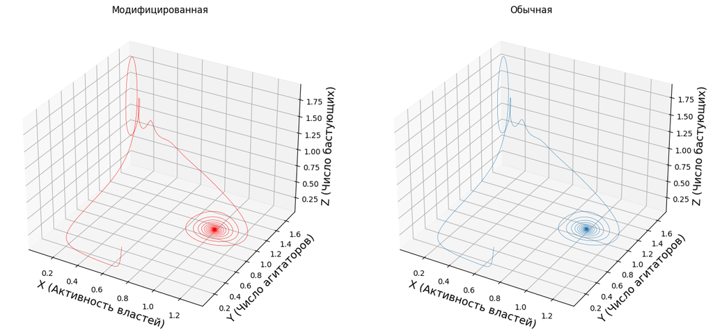

```python
function(a=0.2, b=3.0, c=1.6, m=30, gamma=0.1)
```

```
Параметры модели: x_0 = 0.7, y_0 = 0.1, z_0 = 0.4, a = 0.2, b = 3.0, c = 1.6, m = 30
Коэффициент gamma = 1.5, что составляет 50.0% от b
```

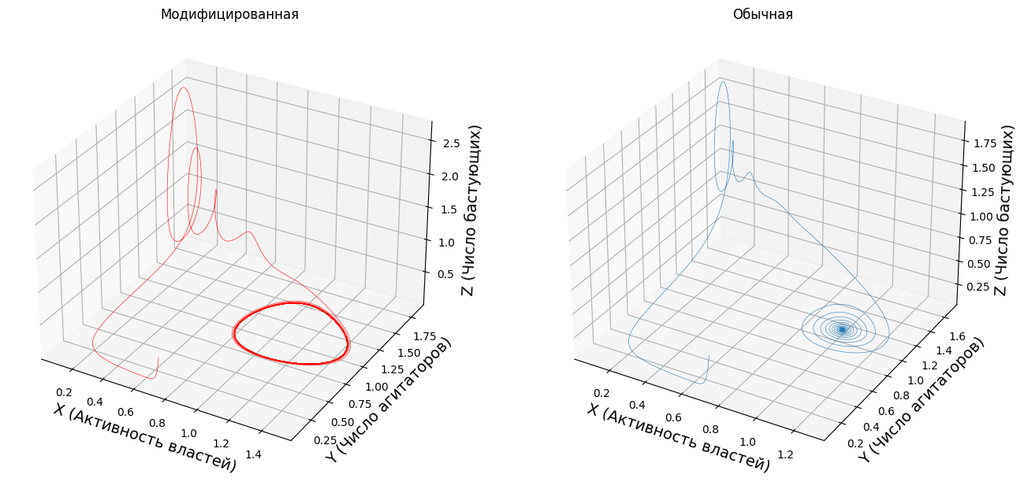

```python
function(a=0.2, b=3.0, c=1.6, m=30, gamma=1.5)
```

```
Параметры модели: x_0 = 0.7, y_0 = 0.1, z_0 = 0.4, a = 0.2, b = 3.0, c = 1.6, m = 30
Коэффициент gamma = 2.999, что составляет 99.97% от b
```

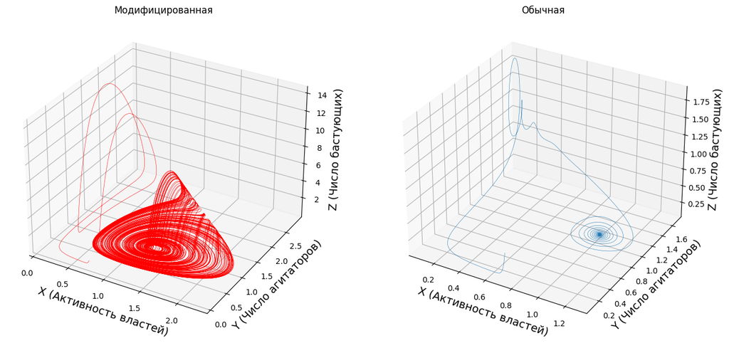

```python
function(a=0.2, b=3.0, c=1.6, m=30, gamma=2.999)
```

## 3. Выводы

Сравнивая полученные результаты, мы пришли к следующим выводам:

В данной работе, мы предположили, что параметр ${\gamma}$, отвечающий за заработную плату, все же оказывает влияние и как показала практика, он действительно повлиял на ход событий. По итогам нашей работы мы пришли к выводу о том, что введённый нами параметр, отвечающий за повышение заработной платы, играет одну из важнейших ролей в поведении системы.

Хочется отметить, что данная модификация является нашим субъективным взглядом на модель.

Спасибо за внимание.

С уважением,  
Виноградов Егор и Михайлов Андрей,  
студенты группы М08-200НД

### Постскриптум.

На наш взгляд, стачки, так или иначе, начинаются с экономической составляющей жизни граждан. На этой волне недовольства любая агитация против действующей власти только усиливает возможности протестов. Со временем протесты действительно перерастут из протестов на экономической почве на почву политическую. Не исключаем также влияния "эффекта толпы", то есть, когда индивидуализм человека сливается с общей массой и "заражается" настроениями толпы. Вообще, рассмотрение стачек интересно изучить даже не с точки зрения математики или истории, а с точки зрения политических технологий. Довольно щепетильная тема, но и не совсем по теме работы.

## ИСТОЧНИКИ:

1. А.Ю. Андреев, Л.И. Бородкин., Нелинейная модель стачечного движения: анализ эффектов самоорганизации. // URL: https://lms.mipt.ru/pluginfile.php/123647/mod_resource/content/0/Андреев%2C%20Бородкин.%20Модель%20стачек.pdf
2. М. Перельман, ЕКАТЕРИНОСЛАВСКАЯ ВСЕОБЩАЯ СТАЧКА 1903 ГОДА. (К 35-летию всеобщих стачек 1903 года). Исторический журнал. 1938. № 8. // URL: https://libmonster.ru/m/articles/view/ЕКАТЕРИНОСЛАВСКАЯ-ВСЕОБЩАЯ-СТАЧКА-1903-ГОДА-К-35-летию-всеобщих-стачек-1903-года
3. Аттрактор. Материал из Википедии — свободной энциклопедии. // URL: https://ru.wikipedia.org/wiki/Аттрактор
4. Differential Equations Course Assignment. // URL: https://github.com/mdmxfry/DE-methods#eq
5. Three-Dimensional Plotting in Matplotlib. Python Data Science Handbook. // URL: https://jakevdp.github.io/PythonDataScienceHandbook/04.12-three-dimensional-plotting.html